# Risk Factor Analysis

## Outcome Variable

**Outcome Variable:** stunted

## Predictor Variables

**Intervention Variable:** vagbrth

**Adjustment Set:**

- arm
- sex
- W_mage
- meducyrs
- feducyrs
- hhwealth_quart
- W_mhtcm
- W_mwtkg
- W_mbmi
- single
- W_nrooms
- brthmon
- W_parity
- impfloor
- delta_W_mage
- delta_meducyrs
- delta_feducyrs
- delta_hhwealth_quart
- delta_W_mhtcm
- delta_W_mwtkg
- delta_W_mbmi
- delta_single
- delta_W_nrooms
- delta_brthmon
- delta_W_parity
- delta_impfloor

## Stratifying Variables

The analysis was stratified on these variable(s):

- agecat
- studyid
- country

## Data Summary

| agecat | studyid | country | vagbrth | stunted | n_cell | n |
| --- | --- | --- | --- | --- | --- | --- |
| Birth | CMC-V-BCS-2002 | INDIA | 0 | 0 | 9 | 92 |
| Birth | CMC-V-BCS-2002 | INDIA | 0 | 1 | 2 | 92 |
| Birth | CMC-V-BCS-2002 | INDIA | 1 | 0 | 66 | 92 |
| Birth | CMC-V-BCS-2002 | INDIA | 1 | 1 | 15 | 92 |
| Birth | IRC | INDIA | 0 | 0 | 58 | 388 |
| Birth | IRC | INDIA | 0 | 1 | 10 | 388 |
| Birth | IRC | INDIA | 1 | 0 | 285 | 388 |
| Birth | IRC | INDIA | 1 | 1 | 35 | 388 |
| Birth | JiVitA-3 | BANGLADESH | 0 | 0 | 418 | 22418 |
| Birth | JiVitA-3 | BANGLADESH | 0 | 1 | 121 | 22418 |
| Birth | JiVitA-3 | BANGLADESH | 1 | 0 | 14626 | 22418 |
| Birth | JiVitA-3 | BANGLADESH | 1 | 1 | 7253 | 22418 |
| Birth | JiVitA-4 | BANGLADESH | 0 | 0 | 57 | 2822 |
| Birth | JiVitA-4 | BANGLADESH | 0 | 1 | 19 | 2822 |
| Birth | JiVitA-4 | BANGLADESH | 1 | 0 | 1908 | 2822 |
| Birth | JiVitA-4 | BANGLADESH | 1 | 1 | 838 | 2822 |
| Birth | NIH-Crypto | BANGLADESH | 0 | 0 | 160 | 477 |
| Birth | NIH-Crypto | BANGLADESH | 0 | 1 | 26 | 477 |
| Birth | NIH-Crypto | BANGLADESH | 1 | 0 | 253 | 477 |
| Birth | NIH-Crypto | BANGLADESH | 1 | 1 | 38 | 477 |
| Birth | PROBIT | BELARUS | 0 | 0 | 1595 | 13893 |
| Birth | PROBIT | BELARUS | 0 | 1 | 2 | 13893 |
| Birth | PROBIT | BELARUS | 1 | 0 | 12264 | 13893 |
| Birth | PROBIT | BELARUS | 1 | 1 | 32 | 13893 |
| Birth | PROVIDE | BANGLADESH | 0 | 0 | 98 | 539 |
| Birth | PROVIDE | BANGLADESH | 0 | 1 | 10 | 539 |
| Birth | PROVIDE | BANGLADESH | 1 | 0 | 393 | 539 |
| Birth | PROVIDE | BANGLADESH | 1 | 1 | 38 | 539 |
| Birth | ZVITAMBO | ZIMBABWE | 0 | 0 | 1076 | 13761 |
| Birth | ZVITAMBO | ZIMBABWE | 0 | 1 | 90 | 13761 |

[output cut: 74 more lines]

The following strata were considered:

- agecat: 24 months, studyid: CMC-V-BCS-2002, country: INDIA
- agecat: 24 months, studyid: IRC, country: INDIA
- agecat: 24 months, studyid: JiVitA-3, country: BANGLADESH
- agecat: 24 months, studyid: JiVitA-4, country: BANGLADESH
- agecat: 24 months, studyid: NIH-Crypto, country: BANGLADESH
- agecat: 24 months, studyid: PROBIT, country: BELARUS
- agecat: 24 months, studyid: PROVIDE, country: BANGLADESH
- agecat: 24 months, studyid: TanzaniaChild2, country: TANZANIA, UNITED REPUBLIC OF
- agecat: 24 months, studyid: ZVITAMBO, country: ZIMBABWE
- agecat: 6 months, studyid: CMC-V-BCS-2002, country: INDIA
- agecat: 6 months, studyid: IRC, country: INDIA
- agecat: 6 months, studyid: JiVitA-3, country: BANGLADESH
- agecat: 6 months, studyid: JiVitA-4, country: BANGLADESH
- agecat: 6 months, studyid: NIH-Crypto, country: BANGLADESH
- agecat: 6 months, studyid: PROBIT, country: BELARUS
- agecat: 6 months, studyid: PROVIDE, country: BANGLADESH
- agecat: 6 months, studyid: TanzaniaChild2, country: TANZANIA, UNITED REPUBLIC OF
- agecat: 6 months, studyid: ZVITAMBO, country: ZIMBABWE
- agecat: Birth, studyid: CMC-V-BCS-2002, country: INDIA
- agecat: Birth, studyid: IRC, country: INDIA
- agecat: Birth, studyid: JiVitA-3, country: BANGLADESH
- agecat: Birth, studyid: JiVitA-4, country: BANGLADESH
- agecat: Birth, studyid: NIH-Crypto, country: BANGLADESH
- agecat: Birth, studyid: PROBIT, country: BELARUS
- agecat: Birth, studyid: PROVIDE, country: BANGLADESH
- agecat: Birth, studyid: ZVITAMBO, country: ZIMBABWE

### Dropped Strata

Some strata were dropped due to rare outcomes:

- agecat: Birth, studyid: CMC-V-BCS-2002, country: INDIA
- agecat: Birth, studyid: PROBIT, country: BELARUS
- agecat: 24 months, studyid: TanzaniaChild2, country: TANZANIA, UNITED REPUBLIC OF

## Methods Detail

We’re interested in the causal parameters $E[Y_a]$ for all values of $a \in \mathcal{A}$. These parameters represent the mean outcome if, possibly contrary to fact, we intervened to set all units to have $A=a$. Under the randomization and positivity assumptions, these are identified by the statistical parameters $\psi_a=E_W[E_{Y|A,W}(Y|A=a,W)]$. In addition, we’re interested in the mean of $Y$, $E[Y]$ under no intervention (the observed mean). We will estimate these parameters by using SuperLearner to fit the relevant likelihood factors – $E_{Y|A,W}(Y|A=a,W)$ and $p(A=a|W)$, and then updating our likelihood fit using a joint TMLE.

For unadjusted analyses ($W=\{\}$), initial likelihoods were estimated using Lrnr_glm to estimate the simple $E(Y|A)$ and Lrnr_mean to estimate $p(A)$. For adjusted analyses, a small library containing Lrnr_glmnet, Lrnr_xgboost, and Lrnr_mean was used.

Having estimated these parameters, we will then use the delta method to estimate relative risks and attributable risks relative to a prespecified baseline level of $A$.

# Results Detail

## Results Plots

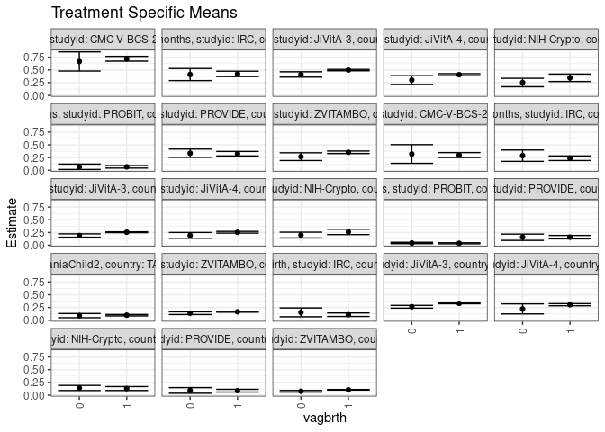

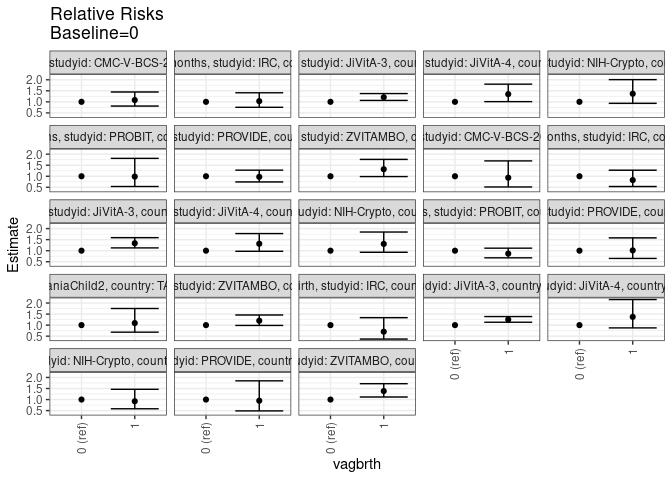

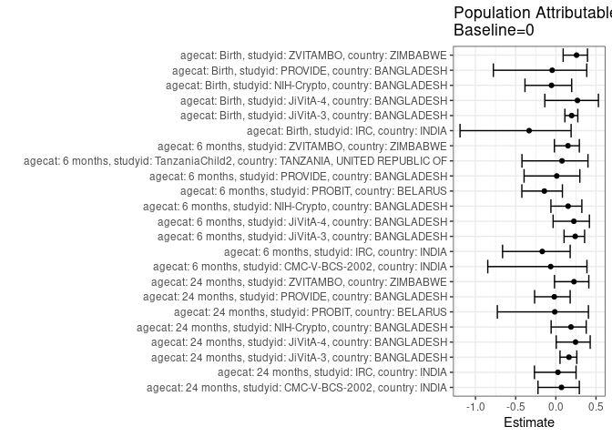

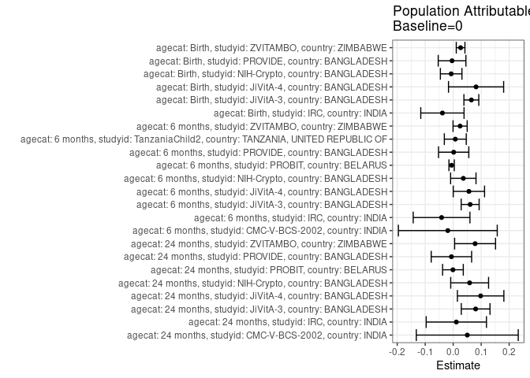

## Results Table

### Parameter: TSM

| agecat | studyid | country | intervention_level | baseline_level | estimate | ci_lower | ci_upper |
| --- | --- | --- | --- | --- | --- | --- | --- |
| Birth | IRC | INDIA | 0 | NA | 0.1545206 | 0.0679178 | 0.2411233 |
| Birth | IRC | INDIA | 1 | NA | 0.1085884 | 0.0744325 | 0.1427442 |
| Birth | JiVitA-3 | BANGLADESH | 0 | NA | 0.2640533 | 0.2371275 | 0.2909792 |
| Birth | JiVitA-3 | BANGLADESH | 1 | NA | 0.3307995 | 0.3232932 | 0.3383057 |
| Birth | JiVitA-4 | BANGLADESH | 0 | NA | 0.2219526 | 0.1234773 | 0.3204279 |
| Birth | JiVitA-4 | BANGLADESH | 1 | NA | 0.3048905 | 0.2843334 | 0.3254476 |
| Birth | NIH-Crypto | BANGLADESH | 0 | NA | 0.1414037 | 0.0915959 | 0.1912115 |
| Birth | NIH-Crypto | BANGLADESH | 1 | NA | 0.1305910 | 0.0919839 | 0.1691981 |
| Birth | PROVIDE | BANGLADESH | 0 | NA | 0.0931104 | 0.0376202 | 0.1486006 |
| Birth | PROVIDE | BANGLADESH | 1 | NA | 0.0881923 | 0.0614336 | 0.1149509 |
| Birth | ZVITAMBO | ZIMBABWE | 0 | NA | 0.0761324 | 0.0602011 | 0.0920636 |
| Birth | ZVITAMBO | ZIMBABWE | 1 | NA | 0.1053901 | 0.1000280 | 0.1107521 |
| 6 months | CMC-V-BCS-2002 | INDIA | 0 | NA | 0.3200000 | 0.1368964 | 0.5031036 |
| 6 months | CMC-V-BCS-2002 | INDIA | 1 | NA | 0.2994186 | 0.2509538 | 0.3478835 |
| 6 months | IRC | INDIA | 0 | NA | 0.2871959 | 0.1755868 | 0.3988050 |
| 6 months | IRC | INDIA | 1 | NA | 0.2373263 | 0.1919134 | 0.2827391 |
| 6 months | JiVitA-3 | BANGLADESH | 0 | NA | 0.1909360 | 0.1583389 | 0.2235332 |
| 6 months | JiVitA-3 | BANGLADESH | 1 | NA | 0.2554011 | 0.2470907 | 0.2637116 |
| 6 months | JiVitA-4 | BANGLADESH | 0 | NA | 0.1938895 | 0.1370679 | 0.2507112 |
| 6 months | JiVitA-4 | BANGLADESH | 1 | NA | 0.2548719 | 0.2377671 | 0.2719767 |
| 6 months | NIH-Crypto | BANGLADESH | 0 | NA | 0.2001692 | 0.1438119 | 0.2565266 |
| 6 months | NIH-Crypto | BANGLADESH | 1 | NA | 0.2618925 | 0.2092809 | 0.3145041 |
| 6 months | PROBIT | BELARUS | 0 | NA | 0.0449627 | 0.0320125 | 0.0579128 |
| 6 months | PROBIT | BELARUS | 1 | NA | 0.0390781 | 0.0287602 | 0.0493960 |
| 6 months | PROVIDE | BANGLADESH | 0 | NA | 0.1571941 | 0.0954678 | 0.2189204 |
| 6 months | PROVIDE | BANGLADESH | 1 | NA | 0.1593994 | 0.1261562 | 0.1926425 |
| 6 months | TanzaniaChild2 | TANZANIA, UNITED REPUBLIC OF | 0 | NA | 0.0907439 | 0.0498007 | 0.1316871 |
| 6 months | TanzaniaChild2 | TANZANIA, UNITED REPUBLIC OF | 1 | NA | 0.0991318 | 0.0853812 | 0.1128825 |
| 6 months | ZVITAMBO | ZIMBABWE | 0 | NA | 0.1386279 | 0.1123877 | 0.1648681 |
| 6 months | ZVITAMBO | ZIMBABWE | 1 | NA | 0.1662664 | 0.1580400 | 0.1744928 |
| 24 months | CMC-V-BCS-2002 | INDIA | 0 | NA | 0.6666667 | 0.4778144 | 0.8555190 |
| 24 months | CMC-V-BCS-2002 | INDIA | 1 | NA | 0.7204611 | 0.6731791 | 0.7677431 |
| 24 months | IRC | INDIA | 0 | NA | 0.4093357 | 0.2909846 | 0.5276869 |
| 24 months | IRC | INDIA | 1 | NA | 0.4219724 | 0.3695315 | 0.4744132 |
| 24 months | JiVitA-3 | BANGLADESH | 0 | NA | 0.4110467 | 0.3586676 | 0.4634258 |
| 24 months | JiVitA-3 | BANGLADESH | 1 | NA | 0.4966815 | 0.4831548 | 0.5102082 |
| 24 months | JiVitA-4 | BANGLADESH | 0 | NA | 0.3014473 | 0.2152886 | 0.3876060 |
| 24 months | JiVitA-4 | BANGLADESH | 1 | NA | 0.4065073 | 0.3872547 | 0.4257599 |
| 24 months | NIH-Crypto | BANGLADESH | 0 | NA | 0.2527515 | 0.1698754 | 0.3356275 |
| 24 months | NIH-Crypto | BANGLADESH | 1 | NA | 0.3453724 | 0.2722523 | 0.4184925 |
| 24 months | PROBIT | BELARUS | 0 | NA | 0.0690614 | 0.0161378 | 0.1219849 |
| 24 months | PROBIT | BELARUS | 1 | NA | 0.0681032 | 0.0434628 | 0.0927436 |
| 24 months | PROVIDE | BANGLADESH | 0 | NA | 0.3350612 | 0.2543130 | 0.4158094 |
| 24 months | PROVIDE | BANGLADESH | 1 | NA | 0.3264954 | 0.2829742 | 0.3700166 |
| 24 months | ZVITAMBO | ZIMBABWE | 0 | NA | 0.2682644 | 0.1922860 | 0.3442428 |
| 24 months | ZVITAMBO | ZIMBABWE | 1 | NA | 0.3537866 | 0.3295223 | 0.3780510 |

### Parameter: E(Y)

| agecat | studyid | country | intervention_level | baseline_level | estimate | ci_lower | ci_upper |
| --- | --- | --- | --- | --- | --- | --- | --- |
| Birth | IRC | INDIA | NA | NA | 0.1159794 | 0.0840777 | 0.1478811 |
| Birth | JiVitA-3 | BANGLADESH | NA | NA | 0.3289321 | 0.3215578 | 0.3363064 |
| Birth | JiVitA-4 | BANGLADESH | NA | NA | 0.3036853 | 0.2836812 | 0.3236894 |
| Birth | NIH-Crypto | BANGLADESH | NA | NA | 0.1341719 | 0.1035529 | 0.1647909 |
| Birth | PROVIDE | BANGLADESH | NA | NA | 0.0890538 | 0.0649864 | 0.1131212 |
| Birth | ZVITAMBO | ZIMBABWE | NA | NA | 0.1026088 | 0.0975387 | 0.1076790 |
| 6 months | CMC-V-BCS-2002 | INDIA | NA | NA | 0.3008130 | 0.2539566 | 0.3476694 |
| 6 months | IRC | INDIA | NA | NA | 0.2457002 | 0.2038248 | 0.2875757 |
| 6 months | JiVitA-3 | BANGLADESH | NA | NA | 0.2515539 | 0.2434271 | 0.2596807 |
| 6 months | JiVitA-4 | BANGLADESH | NA | NA | 0.2500000 | 0.2338924 | 0.2661076 |
| 6 months | NIH-Crypto | BANGLADESH | NA | NA | 0.2363239 | 0.1973320 | 0.2753157 |
| 6 months | PROBIT | BELARUS | NA | NA | 0.0393401 | 0.0293640 | 0.0493162 |
| 6 months | PROVIDE | BANGLADESH | NA | NA | 0.1589404 | 0.1297581 | 0.1881227 |
| 6 months | TanzaniaChild2 | TANZANIA, UNITED REPUBLIC OF | NA | NA | 0.0982544 | 0.0852222 | 0.1112865 |
| 6 months | ZVITAMBO | ZIMBABWE | NA | NA | 0.1633531 | 0.1555398 | 0.1711664 |
| 24 months | CMC-V-BCS-2002 | INDIA | NA | NA | 0.7169811 | 0.6710815 | 0.7628807 |
| 24 months | IRC | INDIA | NA | NA | 0.4205379 | 0.3726382 | 0.4684376 |
| 24 months | JiVitA-3 | BANGLADESH | NA | NA | 0.4912628 | 0.4781447 | 0.5043809 |
| 24 months | JiVitA-4 | BANGLADESH | NA | NA | 0.3995025 | 0.3807924 | 0.4182126 |
| 24 months | NIH-Crypto | BANGLADESH | NA | NA | 0.3115385 | 0.2551365 | 0.3679404 |
| 24 months | PROBIT | BELARUS | NA | NA | 0.0681537 | 0.0420376 | 0.0942697 |
| 24 months | PROVIDE | BANGLADESH | NA | NA | 0.3287197 | 0.2903909 | 0.3670485 |
| 24 months | ZVITAMBO | ZIMBABWE | NA | NA | 0.3465102 | 0.3233236 | 0.3696967 |

### Parameter: RR

| agecat | studyid | country | intervention_level | baseline_level | estimate | ci_lower | ci_upper |
| --- | --- | --- | --- | --- | --- | --- | --- |
| Birth | IRC | INDIA | 0 | 0 | 1.0000000 | 1.0000000 | 1.000000 |
| Birth | IRC | INDIA | 1 | 0 | 0.7027437 | 0.3691053 | 1.337962 |
| Birth | JiVitA-3 | BANGLADESH | 0 | 0 | 1.0000000 | 1.0000000 | 1.000000 |
| Birth | JiVitA-3 | BANGLADESH | 1 | 0 | 1.2527752 | 1.1303870 | 1.388414 |
| Birth | JiVitA-4 | BANGLADESH | 0 | 0 | 1.0000000 | 1.0000000 | 1.000000 |
| Birth | JiVitA-4 | BANGLADESH | 1 | 0 | 1.3736742 | 0.8749487 | 2.156676 |
| Birth | NIH-Crypto | BANGLADESH | 0 | 0 | 1.0000000 | 1.0000000 | 1.000000 |
| Birth | NIH-Crypto | BANGLADESH | 1 | 0 | 0.9235333 | 0.5828159 | 1.463436 |
| Birth | PROVIDE | BANGLADESH | 0 | 0 | 1.0000000 | 1.0000000 | 1.000000 |
| Birth | PROVIDE | BANGLADESH | 1 | 0 | 0.9471798 | 0.4855180 | 1.847819 |
| Birth | ZVITAMBO | ZIMBABWE | 0 | 0 | 1.0000000 | 1.0000000 | 1.000000 |
| Birth | ZVITAMBO | ZIMBABWE | 1 | 0 | 1.3843009 | 1.1160953 | 1.716958 |
| 6 months | CMC-V-BCS-2002 | INDIA | 0 | 0 | 1.0000000 | 1.0000000 | 1.000000 |
| 6 months | CMC-V-BCS-2002 | INDIA | 1 | 0 | 0.9356831 | 0.5162674 | 1.695832 |
| 6 months | IRC | INDIA | 0 | 0 | 1.0000000 | 1.0000000 | 1.000000 |
| 6 months | IRC | INDIA | 1 | 0 | 0.8263567 | 0.5355991 | 1.274956 |
| 6 months | JiVitA-3 | BANGLADESH | 0 | 0 | 1.0000000 | 1.0000000 | 1.000000 |
| 6 months | JiVitA-3 | BANGLADESH | 1 | 0 | 1.3376267 | 1.1255108 | 1.589718 |
| 6 months | JiVitA-4 | BANGLADESH | 0 | 0 | 1.0000000 | 1.0000000 | 1.000000 |
| 6 months | JiVitA-4 | BANGLADESH | 1 | 0 | 1.3145214 | 0.9730458 | 1.775833 |
| 6 months | NIH-Crypto | BANGLADESH | 0 | 0 | 1.0000000 | 1.0000000 | 1.000000 |
| 6 months | NIH-Crypto | BANGLADESH | 1 | 0 | 1.3083554 | 0.9283969 | 1.843817 |
| 6 months | PROBIT | BELARUS | 0 | 0 | 1.0000000 | 1.0000000 | 1.000000 |
| 6 months | PROBIT | BELARUS | 1 | 0 | 0.8691233 | 0.6776763 | 1.114655 |
| 6 months | PROVIDE | BANGLADESH | 0 | 0 | 1.0000000 | 1.0000000 | 1.000000 |
| 6 months | PROVIDE | BANGLADESH | 1 | 0 | 1.0140288 | 0.6505987 | 1.580474 |
| 6 months | TanzaniaChild2 | TANZANIA, UNITED REPUBLIC OF | 0 | 0 | 1.0000000 | 1.0000000 | 1.000000 |
| 6 months | TanzaniaChild2 | TANZANIA, UNITED REPUBLIC OF | 1 | 0 | 1.0924352 | 0.6811225 | 1.752129 |
| 6 months | ZVITAMBO | ZIMBABWE | 0 | 0 | 1.0000000 | 1.0000000 | 1.000000 |
| 6 months | ZVITAMBO | ZIMBABWE | 1 | 0 | 1.1993721 | 0.9865806 | 1.458060 |
| 24 months | CMC-V-BCS-2002 | INDIA | 0 | 0 | 1.0000000 | 1.0000000 | 1.000000 |
| 24 months | CMC-V-BCS-2002 | INDIA | 1 | 0 | 1.0806916 | 0.8080108 | 1.445395 |
| 24 months | IRC | INDIA | 0 | 0 | 1.0000000 | 1.0000000 | 1.000000 |
| 24 months | IRC | INDIA | 1 | 0 | 1.0308710 | 0.7533449 | 1.410635 |
| 24 months | JiVitA-3 | BANGLADESH | 0 | 0 | 1.0000000 | 1.0000000 | 1.000000 |
| 24 months | JiVitA-3 | BANGLADESH | 1 | 0 | 1.2083335 | 1.0625490 | 1.374120 |
| 24 months | JiVitA-4 | BANGLADESH | 0 | 0 | 1.0000000 | 1.0000000 | 1.000000 |
| 24 months | JiVitA-4 | BANGLADESH | 1 | 0 | 1.3485187 | 1.0098638 | 1.800740 |
| 24 months | NIH-Crypto | BANGLADESH | 0 | 0 | 1.0000000 | 1.0000000 | 1.000000 |
| 24 months | NIH-Crypto | BANGLADESH | 1 | 0 | 1.3664507 | 0.9315944 | 2.004292 |
| 24 months | PROBIT | BELARUS | 0 | 0 | 1.0000000 | 1.0000000 | 1.000000 |
| 24 months | PROBIT | BELARUS | 1 | 0 | 0.9861264 | 0.5371494 | 1.810381 |
| 24 months | PROVIDE | BANGLADESH | 0 | 0 | 1.0000000 | 1.0000000 | 1.000000 |
| 24 months | PROVIDE | BANGLADESH | 1 | 0 | 0.9744350 | 0.7437779 | 1.276622 |
| 24 months | ZVITAMBO | ZIMBABWE | 0 | 0 | 1.0000000 | 1.0000000 | 1.000000 |
| 24 months | ZVITAMBO | ZIMBABWE | 1 | 0 | 1.3187982 | 0.9860271 | 1.763875 |

### Parameter: PAR

| agecat | studyid | country | intervention_level | baseline_level | estimate | ci_lower | ci_upper |
| --- | --- | --- | --- | --- | --- | --- | --- |
| Birth | IRC | INDIA | 0 | NA | -0.0385412 | -0.1158547 | 0.0387724 |
| Birth | JiVitA-3 | BANGLADESH | 0 | NA | 0.0648788 | 0.0383463 | 0.0914113 |
| Birth | JiVitA-4 | BANGLADESH | 0 | NA | 0.0817328 | -0.0167564 | 0.1802219 |
| Birth | NIH-Crypto | BANGLADESH | 0 | NA | -0.0072318 | -0.0457568 | 0.0312933 |
| Birth | PROVIDE | BANGLADESH | 0 | NA | -0.0040566 | -0.0534752 | 0.0453620 |
| Birth | ZVITAMBO | ZIMBABWE | 0 | NA | 0.0264765 | 0.0110063 | 0.0419466 |
| 6 months | CMC-V-BCS-2002 | INDIA | 0 | NA | -0.0191870 | -0.1957642 | 0.1573902 |
| 6 months | IRC | INDIA | 0 | NA | -0.0414957 | -0.1428626 | 0.0598713 |
| 6 months | JiVitA-3 | BANGLADESH | 0 | NA | 0.0606179 | 0.0285735 | 0.0926623 |
| 6 months | JiVitA-4 | BANGLADESH | 0 | NA | 0.0561105 | 0.0002030 | 0.1120180 |
| 6 months | NIH-Crypto | BANGLADESH | 0 | NA | 0.0361546 | -0.0092401 | 0.0815493 |
| 6 months | PROBIT | BELARUS | 0 | NA | -0.0056226 | -0.0151969 | 0.0039518 |
| 6 months | PROVIDE | BANGLADESH | 0 | NA | 0.0017463 | -0.0523289 | 0.0558214 |
| 6 months | TanzaniaChild2 | TANZANIA, UNITED REPUBLIC OF | 0 | NA | 0.0075105 | -0.0316375 | 0.0466584 |
| 6 months | ZVITAMBO | ZIMBABWE | 0 | NA | 0.0247252 | -0.0005099 | 0.0499603 |
| 24 months | CMC-V-BCS-2002 | INDIA | 0 | NA | 0.0503145 | -0.1317778 | 0.2324068 |
| 24 months | IRC | INDIA | 0 | NA | 0.0112021 | -0.0964713 | 0.1188756 |
| 24 months | JiVitA-3 | BANGLADESH | 0 | NA | 0.0802161 | 0.0289280 | 0.1315042 |
| 24 months | JiVitA-4 | BANGLADESH | 0 | NA | 0.0980552 | 0.0150784 | 0.1810319 |
| 24 months | NIH-Crypto | BANGLADESH | 0 | NA | 0.0587870 | -0.0088425 | 0.1264164 |
| 24 months | PROBIT | BELARUS | 0 | NA | -0.0009077 | -0.0378915 | 0.0360761 |
| 24 months | PROVIDE | BANGLADESH | 0 | NA | -0.0063415 | -0.0785431 | 0.0658602 |
| 24 months | ZVITAMBO | ZIMBABWE | 0 | NA | 0.0782458 | 0.0051377 | 0.1513539 |

### Parameter: PAF

| agecat | studyid | country | intervention_level | baseline_level | estimate | ci_lower | ci_upper |
| --- | --- | --- | --- | --- | --- | --- | --- |
| Birth | IRC | INDIA | 0 | NA | -0.3323106 | -1.1922646 | 0.1903115 |
| Birth | JiVitA-3 | BANGLADESH | 0 | NA | 0.1972406 | 0.1126695 | 0.2737513 |
| Birth | JiVitA-4 | BANGLADESH | 0 | NA | 0.2691363 | -0.1369967 | 0.5301994 |
| Birth | NIH-Crypto | BANGLADESH | 0 | NA | -0.0538993 | -0.3838947 | 0.1974074 |
| Birth | PROVIDE | BANGLADESH | 0 | NA | -0.0455520 | -0.7773843 | 0.3849507 |
| Birth | ZVITAMBO | ZIMBABWE | 0 | NA | 0.2580331 | 0.0913121 | 0.3941650 |
| 6 months | CMC-V-BCS-2002 | INDIA | 0 | NA | -0.0637838 | -0.8471227 | 0.3873521 |
| 6 months | IRC | INDIA | 0 | NA | -0.1688874 | -0.6630020 | 0.1784149 |
| 6 months | JiVitA-3 | BANGLADESH | 0 | NA | 0.2409737 | 0.1025292 | 0.3580616 |
| 6 months | JiVitA-4 | BANGLADESH | 0 | NA | 0.2244419 | -0.0337124 | 0.4181260 |
| 6 months | NIH-Crypto | BANGLADESH | 0 | NA | 0.1529876 | -0.0610792 | 0.3238676 |
| 6 months | PROBIT | BELARUS | 0 | NA | -0.1429216 | -0.4228999 | 0.0819664 |
| 6 months | PROVIDE | BANGLADESH | 0 | NA | 0.0109870 | -0.3951235 | 0.2988817 |
| 6 months | TanzaniaChild2 | TANZANIA, UNITED REPUBLIC OF | 0 | NA | 0.0764390 | -0.4215559 | 0.3999780 |
| 6 months | ZVITAMBO | ZIMBABWE | 0 | NA | 0.1513605 | -0.0180736 | 0.2925964 |
| 24 months | CMC-V-BCS-2002 | INDIA | 0 | NA | 0.0701754 | -0.2220596 | 0.2925274 |
| 24 months | IRC | INDIA | 0 | NA | 0.0266377 | -0.2663009 | 0.2518096 |
| 24 months | JiVitA-3 | BANGLADESH | 0 | NA | 0.1632855 | 0.0522056 | 0.2613471 |
| 24 months | JiVitA-4 | BANGLADESH | 0 | NA | 0.2454433 | 0.0050098 | 0.4277774 |
| 24 months | NIH-Crypto | BANGLADESH | 0 | NA | 0.1886990 | -0.0585207 | 0.3781800 |
| 24 months | PROBIT | BELARUS | 0 | NA | -0.0133185 | -0.7277397 | 0.4056892 |
| 24 months | PROVIDE | BANGLADESH | 0 | NA | -0.0192915 | -0.2644933 | 0.1783625 |
| 24 months | ZVITAMBO | ZIMBABWE | 0 | NA | 0.2258110 | -0.0167903 | 0.4105287 |